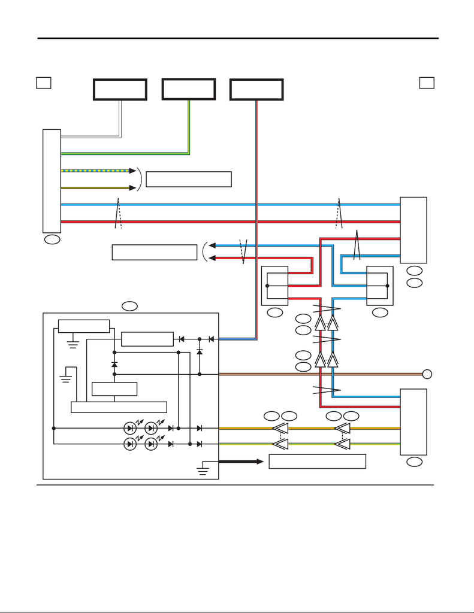

WI-73

Airbag System

WIRING SYSTEM

6. Airbag System

A: WIRING DIAGRAM

WI-44283

7

17

1

A

i230 B552

AB6

B40

8

4

14

5

B/Y

16

L

6R

W

G/Y

W

G/Y

1

MFD

i122

A

A23

A17

A22

A13

L

B28L

B20R

C27R

C35L

R

A10

A3

A11

Y/L

A2

B

Y/R

BR/W

BR/W

L/RA1

Y/R Y/R

Y/L

5

6

B31 AB1

Y/L

L/R

:

C: i84

B: B281

A:

i232 i233

6

7

B551

i229

1

2

AB65

B556

2

2

L

L

2L

2

2

R

2R

R

R

L

L

R

2

: TERMINAL No. OPTIONAL ARRANGEMENT

REF. TO MULTI-FUNCTION DISPLAY (MFD)

SYSTEM [a]

IG DETECTING

CIRCUIT

PASSENGER'S AIRBAG OFF

PASSENGER'S AIRBAG ON

AIRBAG CM

BODY

INTEGRATED

UNIT

MICRO COMPUTER

FB-10

M/B FUSE NO. 8

(B)

REF. TO ENGINE ELECTRICAL

SYSTEM [1g] [2g] [3f] [4f]

REF. TO CAN COMMUNICATION

SYSTEM [b]

DATA LINK

CONNECTOR

MB-27

M/B FUSE NO. 13

(B)

FB-32

F/B FUSE NO. 4

(IG)

CONSTANT VOLTAGE

CIRCUIT

CONSTANT VOLTAGE

CIRCUIT

: ENGINE TYPE FA : B/R

ENGINE TYPE EJ : B/W

J/C J/C

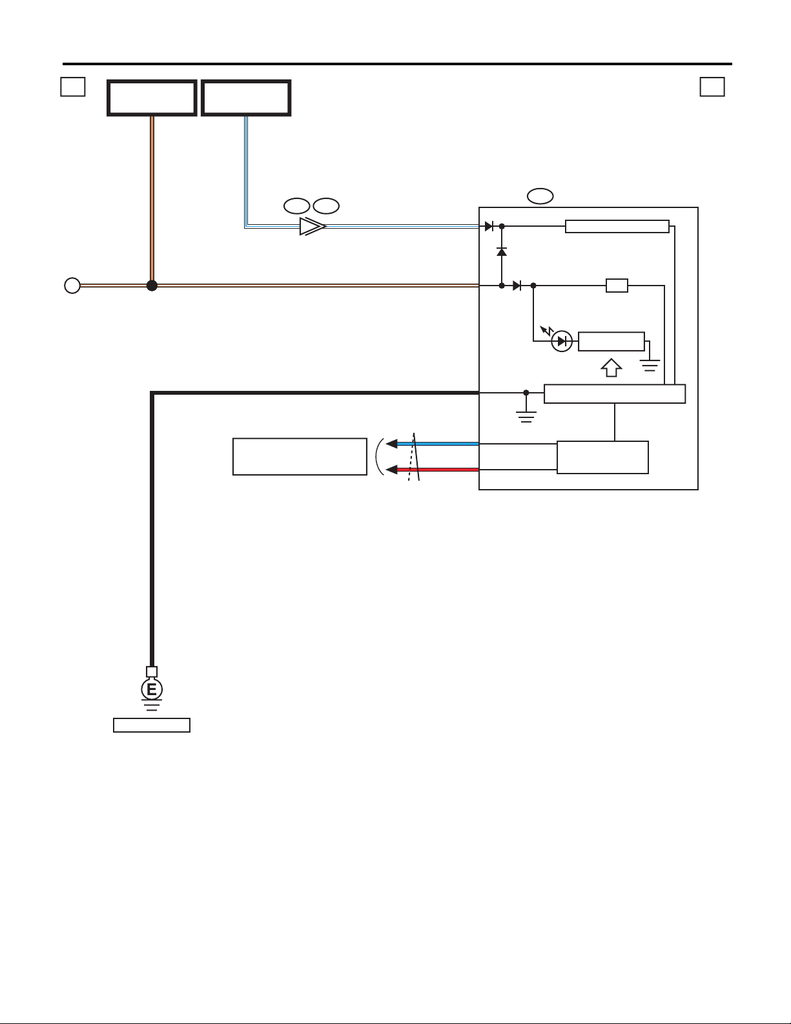

WI-74

Airbag System

WIRING SYSTEM

WI-44284

3

b b

I/F

B551 i229

i10

A

B

BR/W

BR/W

W/L

B38

20BR/W

W/L 40

L32

R33

W/L W/L

COMBINATION METER

FB-18

F/B FUSE NO. 7

(B)

FB-12

F/B FUSE NO. 2

(IG)

AIRBAG

CAN TRANSCEIVER &

RECEIVER

DRIVE CIRCUIT

POWER SUPPLY CIRCUIT

MICRO COMPUTER

REF. TO GND [e]

REF. TO CAN COMMUNICATION

SYSTEM [b]

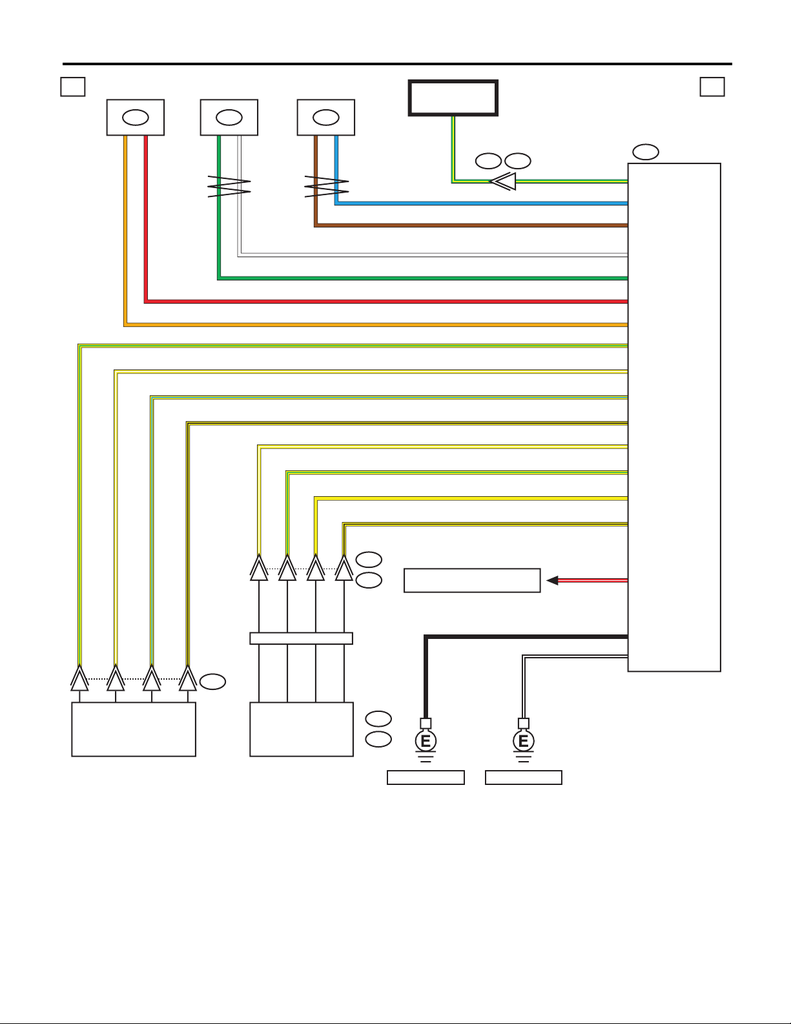

WI-75

Airbag System

WIRING SYSTEM

WI-44285

1

c c

AB2

AB7

AB9

1

2

4

3

B: AB38

A: AB37

A:

AB16AB13

AB6

AB66

B31 AB1

2

1

B1

B2

Y/L

Y/W

Y/G

Y/B

Y

3

A1 Y/G

4

A2 Y/W

Y/B

B/W

B

A3

A4

B/W

B

A26

Y/B

Y

A6

A5

Y/G A8

Y/W A7

Y/B

Y/L

A2Y/W

A1Y/G

A25

R/W A15

G2

W1

O2

R1

BR 2

L1

G

W A28

A30

RA9

O A10

BR

L A27

G/Y A21

A29

G/Y

G/Y G/Y

FB-41

F/B FUSE NO. 25

(IG)

DRIVER'S KNEE

AIRBAG MODULE

AIRBAG CM

FRONT

SUB SENSOR RH

FRONT

SUB SENSOR LH

PASSENGER'S AIRBAG MODULE DRIVER'S AIRBAG MODULE

ROLL

CONNECTOR

REF. TO SEAT BELT WARNING

SYSTEM [a]

REF. TO GND [d]REF. TO GND [d]

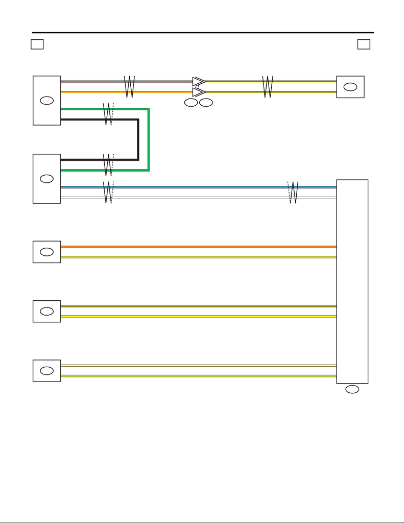

WI-76

Airbag System

WIRING SYSTEM

WI-44286

2

1

d d

AB23

AB32

AB31

AB19

AB21

AB58

R123 AB62

AB17

B

G

L

W

1

2

3

4

B15

B8

B7

B6

Y/W

Y/G

1

2

B9

B10

Y/B

Y

2

3

B2

B1

Y/R

Y/L

L

2Y/R

1Y/B

W

Y/W

Y/G

Y/B

Y

Y/R

Y/L

2

1

G

B

3

4

B/L

O

1

2

O

Y/B

B/L

Y/R

B:

FRONT DOOR IMPACT

SENSOR LH

PRETENSIONER

LH

SIDE AIRBAG

MODULE LH

CURTAIN AIRBAG

MODULE LH

AIRBAG CM

CURTAIN AIRBAG

SENSOR LH

SIDE AIRBAG

SENSOR LH

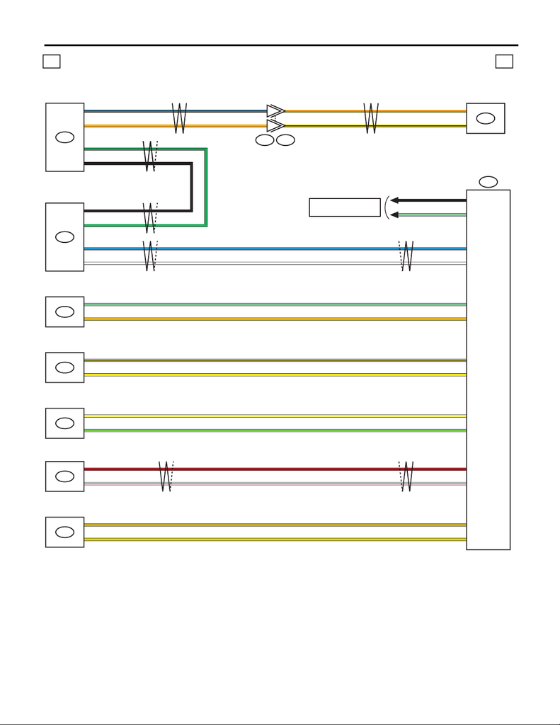

WI-77

Airbag System

WIRING SYSTEM

WI-44287

2

1

e e

AB28

AB18

AB30

AB33

AB24

AB26

AB41

AB34

AB64

R124 AB63

B

G

L

W

1

2

3

4

L C11

WC8

Y/BR C1

Y/O C2

Y/BR

Y/O

1

2

Y/W C9

Y/G C10

Y/W

Y/G

1

2

Y/B C7

YC6

Y/B

Y

2

3

Y/L C5

Y/R C4

B C12

LG C13

Y/L

Y/R

1

2

G

B

3

4

R/B C14

W/R C15

R/B

W/R

1

2

2Y/R

1Y/B

B/L

O

1

2

O

Y/B

B/L

Y/R

C:

FRONT DOOR IMPACT

SENSOR RH

CURTAIN AIRBAG

SENSOR RH

REF. TO OCCUPANT

DETECTION SYSTEM [b]

SATELLITE SAFING

SENSOR

PRETENSIONER

RH

SIDE AIRBAG

MODULE RH

CURTAIN AIRBAG

MODULE RH

LAP SEAT BELT

PRETENSIONER

RH

AIRBAG CM

SIDE AIRBAG

SENSOR RH

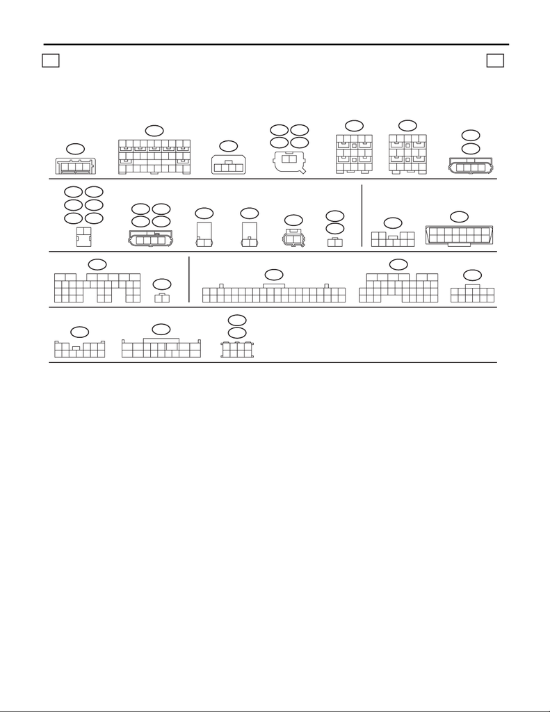

WI-78

Airbag System

WIRING SYSTEM

AB37

(O)

A:

1

2

AB38

(B)

B:

1

2

WI-44288

f f

3

4

12

AB2

(Y)

8

9

10

11 12 13 14

15 16 17 18 19 20

21 22 23 24 25 26 27 28 29 30

AB6

(Y)

(Y)

AB18

(Y)

AB17

AB63

AB62

AB24

(Y)

AB19

(Y)

AB28

AB23

AB34

AB32

(Y)

(Y)

(GR)

(Y)

(Y)

(Y)

(Y)

AB9

AB30

AB26

AB21

AB66

AB33

AB31

(B)

(B)

(B)

(B)

(B)

(B)

AB16

AB13

AB64

AB58

(Y)

(Y)

(Y)

(Y)

(Y)

AB41

A:

B:

C:

3

421

21

12

12345

67

8

9

10

11 12 13 14

15

1524

10

9

1514

67

11 12

3

8

13

1234

12

1234

21

B31

8765

21

10

9

43

B40

(B)

1

9

8

16

2

10

7

15

3

11

6

14

4

12

5

13

i10

11 12

9

10

2

15 1613 14 19

18

20

21 22 23 24 26

25

27 28 29 30 31 32 33 34 35 36 37 38 39 40

17

i122

(B)

A:

11 12

9

10

78

65341

2

i230

(GR)

10

13

345 6

14 15 16 17

1211

12 78

9

B281B:

29

10 11 12 13 14 15

2524

16

30

98

17 18 19

20

28

21 22 23

3231

26 27

33 34 35

i84C:

19

18

21

20

2322 24 25 26

17

1

23

4

56

27

28 29 30

31 32 33 34 35

798

151413121110 16

i229

12 345

6789

10 11 12

i233

i232

78

5

6

34

21

B556

21

LIST OF CONNECTORS